# A Titanic Model

## Workbook

- You can run the code in these slides by opening `02-data-frames.R` and following along.
- **ALL** of the code you see on the screen today is in your workbook.
- You will learn more if you see the code run for yourself.
  - *This is technically an untested hypothesis. Sorry.*
- There are a few code examples I have had to comment out in order for my slides to build correctly. Feel free to uncomment most of this code (unless it is otherwise noted).
  - RStudio Shortcut - [CTRL]+[SHIFT]+c

## Learning Objectives

- Logistic Regression
- Prediction
- Export CSV
- Kaggle

#### Disclaimer:

Everyone is getting tired and we've been working at this for nearly three hours. I am going to avoid going into too much detail, but will show you enough code to get you started.

## Definition: Predictive Model

According to Wikipedia:

Predictive modeling leverages statistics to predict outcomes. Most often the event one wants to predict is in the future, but predictive modeling can be applied to any type of unknown event, regardless of when it occurred.

- *This is a relief. Titanic sank over 100 years ago and we still haven't figured it out.*

## About These Predictions

- Will use train.csv to predict survival in test.csv.
- I do not have the answers. You could look them up, but that's lame.
- When I say a projection is correct xx% of the time, I am repeating what Kaggle told me.
  - Leader board comments are from early October, 2015.
  - *YMMV (I promise it will)*.
- Feel free to get a Kaggle account, use this code, and out-score me.
- The model is simplistic
- I promise, you can improve it.
- I will give you some links at the end for further reading.

## Kaggle

- https://www.kaggle.com/c/titanic
- Discuss the "project".
- Discuss the leaderboard.

## Import Data

```r
## Imports the training data.
ti_train <- read.csv("data/train.csv")
names(ti_train) <- tolower( names(ti_train) )

## Imports the test data.
ti_test <- read.csv("data/test.csv")
names(ti_test) <- tolower( names(ti_test) )
```

## Time To Build Some Models!

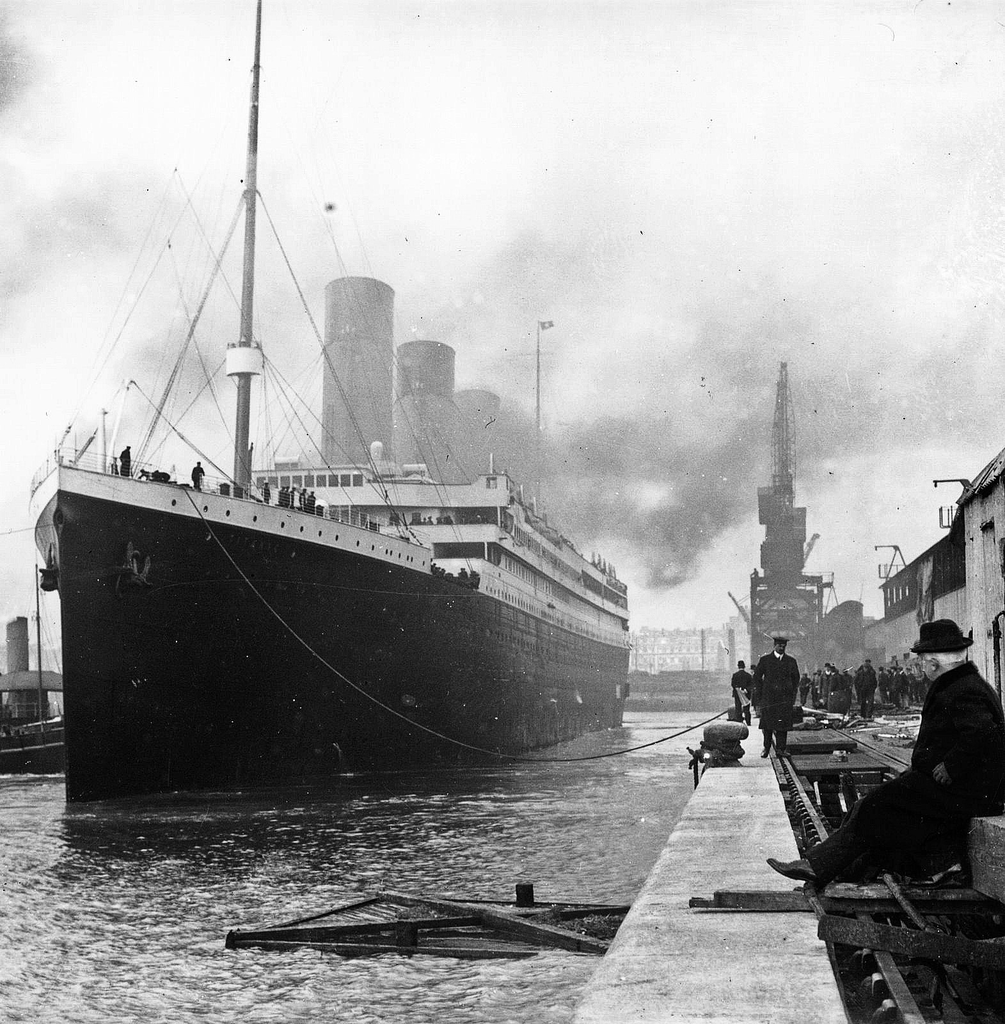

## Model 1 - Everyone Lives!

- We know 62% of the passengers died.
- But what will happen if we assume everyone lives?

```r
## This is, quite possibly the world's worst Titanic model.
## This is really here to demonstrate cbind() and write.csv().
## And the laughs. Mostly the laughs.
model_stupid = cbind( passengerid = ti_test$passengerid, survived=1 )
write.csv(model_stupid, file = "models/stupid.csv", row.names=FALSE)
```

- Model "Stupid" earned me a score of 3,175 on the leader board (of 3,178).
- My model was a correct only 37.321 percent of the time.
- There are three people who actually built a worse model!

## Model 2 - Everyone Dies!

```r
## This just can't be as bad. It just can't be.
## This really is here for completeness and the laughs.
model_everyone_dies = cbind( passengerid = ti_test$passengerid, survived=0 )
write.csv(model_everyone_dies, file = "models/everyone-dies.csv", row.names=FALSE)
```

- I predict this works out better. . . for us.

## Model 2 - Everyone Dies! Continued

- This model bumped us up 82 positions on the leaderboard.
- We are now sitting in position 3,093.
- I'm a little concerned at this point that there are so many models that perform worse than this.
- The model is correct 62.679 percent of the time.
- This is basically what we should expect, given what we say in the `ti_train` data.

## Model 3

- We know women were more likely to survive.
- Let's use logistic regression to model this (and build a real model).
- By default, R will return NA when there are missing variables. and
- Kaggle rejects submitted data with missing rows.
- This means we can't easily use some data columns.

## Model 3 - Sex

- Example of how to build a SIMPLE model using R's glm function.
- family=binomial `->` We are using logistic regression.
- No output on this slide, because it doesn't fit.

```r
## Builds a model using sex to predict survival.
model_sex <- glm( survived ~ sex, family = binomial, data = ti_train )
model_sex
```

- Deviance falls from 1186.7 (null) to 917.8 (model).
- Sex is predictive of survival.
- Yes, this is a simplistic interpretation.

## Model 3 - Sex

#### Model 3: Results:

```
##
## Call:  glm(formula = survived ~ sex, family = binomial, data = ti_train)
##
## Coefficients:
## (Intercept)      sexmale
##       1.057       -2.514
##
## Degrees of Freedom: 890 Total (i.e. Null);  889 Residual
## Null Deviance:       1187
## Residual Deviance: 917.8     AIC: 921.8
```

## Model 3 - Sex Plotted

- I simply cannot put this into a slide.
- It is an interactive function, which helps you visualize the model.
- But, you can run it on your computer.

```r
## You can visually look at your model
## by using plot(). This code is commented out
## because this doesn't export to HTML well.
plot(model_sex)
```

## Model 3 - Sex Prediction

```r
## Creates a new vector, called survived.
## Predict.glm takes model_sex and applies it to ti_test.
survived <- predict.glm(model_sex,
                        newdata = ti_test,
                        type = "response"
                        )

## We round these off, because Kaggle's survival rules are clear.
## The survived col must be 1 or 0.
survived <- round(survived,0)

write.csv(cbind(passengerid = ti_test$passengerid, survived = survived)
          ,file = "models/sex.csv"
          ,row.names=FALSE
         )
```

## Model 3 - Sex Prediction Continued

- This improved our standings on the leaderboard by 479 positions.
- The model is now 76.555 percent accurate.

## Model 4

- We know age matters, but age is funky because of missing data.
- So we won't use it.
- Another useful factor is passenger class.

## Model 4 - Passenger Class

```r
## Uses sex + pclass to predict survival.
model_sex_pclass <- glm( survived ~ sex + pclass, family = binomial, data = ti_train )
model_sex_pclass
```

- Deviance falls from 1186.7 (null) to 827.2 (model).
- Sex + Passenger Class is predictive of survival.
- This is *still* a highly simplistic interpretation!

## Model 4 - Passenger Class

#### Model 4: Results:

```
##
## Call:  glm(formula = survived ~ sex + pclass, family = binomial, data = ti_train)
##
## Coefficients:
## (Intercept)      sexmale       pclass
##      3.2946      -2.6434      -0.9606
##
## Degrees of Freedom: 890 Total (i.e. Null);  888 Residual
## Null Deviance:       1187
## Residual Deviance: 827.2     AIC: 833.2
```

## Model 4 - Passenger Class Prediction

```r
## Creates a new vector, called survived.
## Predict.glm takes model_sex_pclass and applies it to ti_test.
survived <- predict.glm(model_sex_pclass,
                        newdata = ti_test,
                        type = "response"
                        )

## We round these off, because Kaggle's survival rules are clear.
## The survived col must be 1 or 0.
survived <- round(survived,0)

write.csv(cbind(passengerid = ti_test$passengerid, survived = survived)
          ,file = "models/sex+pclass.csv"
          ,row.names=FALSE
         )
```

## Model 4 - Passenger Class Prediction Continued

- The model is still only 76.555 percent accurate.
- :-(
- Does demonstrate how to build a model with multiple predictors.

## Model 5 - Last Model

- We know Passenger Class matters
- We know Sex matters.
- But, just adding pclass to the model didn't help us.
- But, what about the interaction between the two?
- Let's try it.

## Model 5 - Interactions

```r
## This is our last model.
## Uses sex * pclass (interaction) to predict survival.
model_interaction <- glm( survived ~ sex * pclass, family = binomial, data = ti_train )
model_interaction
```

- Deviance falls from 1186.7 (null) to 803.12 (model).
- Sex * Passenger Class is predictive of survival.

## Model 5 - Interaction

#### Model 5: Results:

```
##
## Call:  glm(formula = survived ~ sex * pclass, family = binomial, data = ti_train)
##
## Coefficients:
##    (Intercept)         sexmale          pclass  sexmale:pclass
##          6.042          -6.049          -2.001           1.359
##
## Degrees of Freedom: 890 Total (i.e. Null);  887 Residual
## Null Deviance:       1187
## Residual Deviance: 803.1     AIC: 811.1
```

## Model 5 - Interaction Prediction

```r
## Creates a new vector, called survived.
## Predict.glm takes model_sex_pclass and applies it to ti_test.
survived <- predict.glm(model_interaction,
                        newdata = ti_test,
                        type = "response"
                        )

## We round these off, because Kaggle's survival rules are clear.
## The survived col must be 1 or 0.
survived <- round(survived,0)

write.csv(cbind(passengerid = ti_test$passengerid, survived = survived)
          ,file = "models/interaction.csv"
          ,row.names=FALSE
         )
```

## Model 5 - Interaction Continued

- The model is still only 76.555 percent accurate.
- :-(
- Does demonstrate how to build a model with interactions.

## Model 5 - Summary()

- One way to get a better understanding of what is going on in the model is to use the summary() command.
- This will return LOTS of detail.
- We need a new slide.

```r
## Using summary() on a model returns lots of info.
summary(model_interaction)
```

## Model 5 - Summary()

```
##
## Call:
## glm(formula = survived ~ sex * pclass, family = binomial, data = ti_train)
##
## Deviance Residuals:
##     Min       1Q   Median       3Q      Max
## -2.8488  -0.6969  -0.5199   0.4946   2.0339
##
## Coefficients:
##                Estimate Std. Error z value Pr(>|z|)
## (Intercept)      6.0416     0.8273   7.303 2.81e-13 ***
## sexmale         -6.0493     0.8756  -6.909 4.88e-12 ***
## pclass          -2.0011     0.2950  -6.784 1.17e-11 ***
## sexmale:pclass   1.3593     0.3202   4.245 2.19e-05 ***
## ---
## Signif. codes:  0 '***' 0.001 '**' 0.01 '*' 0.05 '.' 0.1 ' ' 1
##
## (Dispersion parameter for binomial family taken to be 1)
##
##     Null deviance: 1186.66  on 890  degrees of freedom
## Residual deviance:  803.12  on 887  degrees of freedom
## AIC: 811.12
##
## Number of Fisher Scoring iterations: 6
```

## Model X - Your Turn

- The truth is, it is going to be hard to do much more, without pulling in other columns, and that means more data management / munging.
- This is as far as I'm prepared to take us today.
- Feel free to look at the data, build models and ask questions.
- Look at age. If you can fix the NAs, there is some information there.

## Have Fun Over-Fitting!

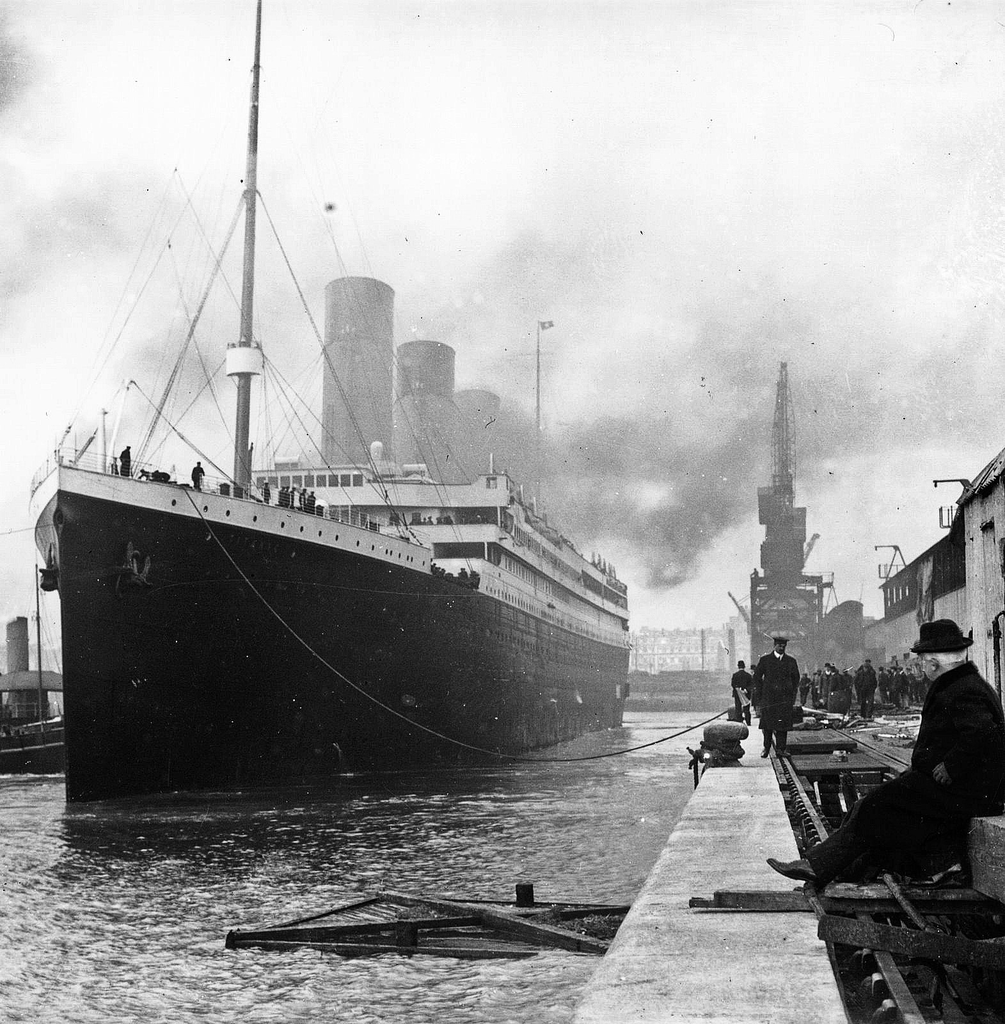